# Statistics

Dr. Polla Fattah

# What You Will Learn

By the end of this crash course, you’ll be able to:

- Summarize and visualize data
- Measure variability and shape
- Construct and interpret confidence intervals
- Conduct hypothesis testing (t-tests, ANOVA, chi-square)
- Analyze categorical and numeric outcomes
- Choose appropriate statistical tests for your thesis
- Communicate statistical results effectively

# Key Questions Every Researcher Must Answer

- Does my algorithm really perform better than others?
- How confident can I be in my results?
- Is the difference I observed due to chance?
- How do I report my findings objectively?

Statistics provides the **language of evidence** in science.

**Why Postgraduates Can’t Ignore Statistics**

Without statistical analysis, a statement like:

> “I ran my new sorting algorithm and it seemed faster than QuickSort.”  
> is anecdotal at best.

In a thesis defense, your examiners will ask:

- How many times did you test it?
- What was the average run-time?
- How much variability was there?
- Could this be due to randomness?
- Was your test design valid?

These are not programming questions — they are **statistical**.

# Statistics in Experimental Design and Validation

| Activity | Statistical Role |
| --- | --- |
| Comparing algorithms | t-tests, ANOVA |
| Classifier performance | Confidence intervals |
| Survey data | Chi-square, proportions |
| Benchmarking systems | Regression |
| System reliability | Error rate, standard deviation |

Good experimental design includes:

- Stating clear hypotheses
- Designing fair trials
- Collecting and summarizing results
- Performing appropriate statistical analysis

# Our Guiding Scenario: The Algorithm Showdown

To make this course practical, we’ll follow one running example:

> You’re defending your MSc thesis:

> **“Comparing MergeSort and QuickSort performance.”**

You’ve:

- Run each algorithm 30 times
- Recorded run-time (ms)
- Collected performance data

Your core research question:  
> *“Is MergeSort significantly faster than QuickSort?”*

We will use this example throughout to introduce and apply statistical concepts.

# Descriptive Statistics: Center and Spread

To begin answering our thesis question (“Is MergeSort faster than QuickSort?”), we need to **describe** the data.

We’ll start with:

- Measures of central tendency
- Measures of variability
- How they behave in symmetric and skewed data
- Practical examples with our simulated results

# Understanding Central Tendency

**Central tendency** describes the “middle” of the data — where values tend to cluster.

Three common measures:

- **Mean**: Arithmetic average
- **Median**: Middle value when sorted
- **Mode**: Most frequent value (less useful in continuous data)

**When Do These Measures Differ?**

In a perfectly **symmetric distribution**, all three measures are equal:

$$\text{Mean} = \text{Median} = \text{Mode}$$

In a **right-skewed** distribution (tail on the right):

**Mean > Median > Mode**

In a **left-skewed** distribution (tail on the left):

**Mean < Median < Mode**

This helps analysts infer the **shape** of the data from summary statistics.

# Simulating Our Data (QuickSort vs MergeSort)

We’ll work with the following data throughout this presentation:

```r
set.seed(42)
qs <- rnorm(30, mean = 52, sd = 6)
ms <- rnorm(30, mean = 48, sd = 5)

algo_data <- data.frame(
  Algorithm = rep(c("QuickSort", "MergeSort"), each = 30),
  Time_ms = c(qs, ms)
)
```

Each row represents one run of either algorithm. We’ll use this data in visualizations and statistical analysis.

# Displaying the Data as a Table

It’s useful to see the actual values used:

| Trial | QuickSort | MergeSort |
| --- | --- | --- |
| 1 | 60.23 | 50.28 |
| 2 | 48.61 | 51.52 |
| 3 | 54.18 | 53.18 |
| 4 | 55.80 | 44.96 |
| 5 | 54.43 | 50.52 |
| 6 | 51.36 | 39.41 |
| 7 | 61.07 | 44.08 |
| 8 | 51.43 | 43.75 |
| 9 | 64.11 | 35.93 |
| 10 | 51.62 | 48.18 |

# Mean and Median of Each Algorithm

```r
mean(qs); median(qs)
```

```
## [1] 52.41152
```

```
## [1] 51.39765
```

Do the mean and median differ? That can tell us about symmetry or skewness.

# Visualizing the Center of Data

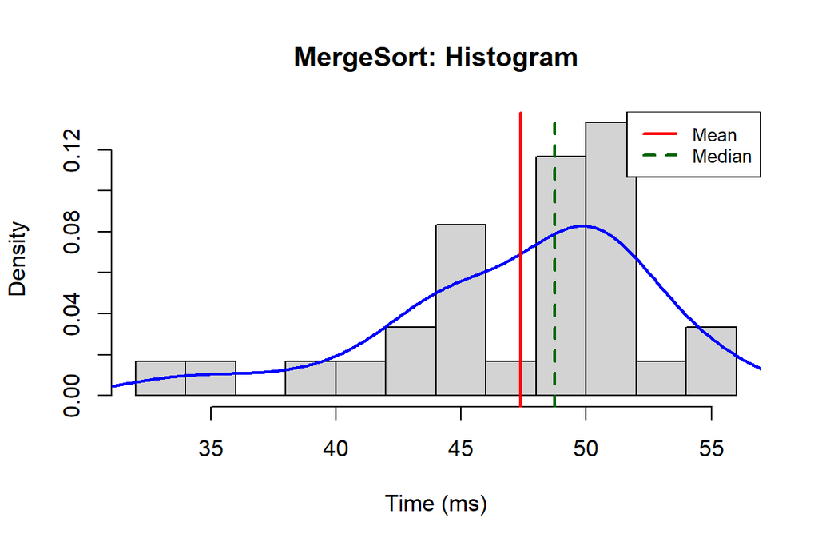

# Understanding Variability

Two datasets can have the same mean but very different **spread**. Measures of variability include:

- **Range**: max - min
- **Deviations** from the mean
- **Variance**: average squared deviation
- **Standard Deviation (SD)**: square root of variance
- **IQR**: interquartile range (Q3 - Q1)

# Why Standard Deviation?

Standard deviation (SD) is the most common way to quantify **how much the data spread** around the mean.

- Low SD = tightly clustered
- High SD = widely spread

```r
tapply(algo_data$Time_ms, algo_data$Algorithm, sd)
```

```
## MergeSort QuickSort
##  5.250282  7.530168
```

# Boxplots: A Visual Summary

Boxplots show:

- Median (center line)
- Q1 and Q3 (box edges)
- IQR (box width)
- Outliers (dots beyond whiskers)

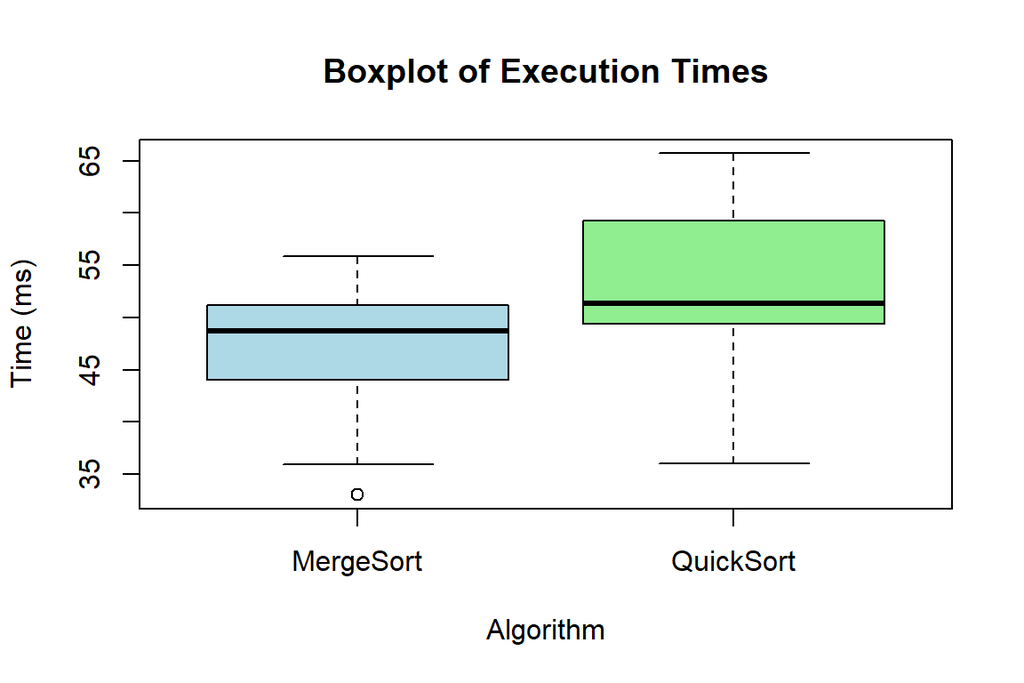

# What Can Boxplots Tell Us?

Boxplots help you:

- Compare medians
- Spot skewed distributions (asymmetry)
- Detect outliers
- Evaluate overall spread (IQR vs total range)

Use them early and often during data exploration!

# Distributions and Statistical Assumptions

Before conducting statistical tests, we must understand **how the data are distributed**.

This section covers:

- What distributions are
- The normal (bell-shaped) distribution
- How to assess normality in R
- When and why normality matters

# What Is a Distribution?

A **distribution** describes how values are spread out.

Key properties:

- **Symmetry** vs **skewness**
- **Unimodal** vs **bimodal**
- **Continuous** vs **discrete**

Examples:

- Uniform: all values equally likely
- Normal: bell-shaped
- Skewed: lopsided toward one side

# The Normal Distribution

The **normal distribution** (Gaussian) is:

- Symmetric
- Bell-shaped
- Defined by **mean** and **standard deviation**

In a normal distribution:

- Mean = Median = Mode
- Most values lie near the center

# The Empirical Rule

The **Empirical Rule** states:

- ~68% of data lie within **±1 SD**
- ~95% within **±2 SD**
- ~99.7% within **±3 SD**

This rule is essential for:

- Understanding **confidence intervals**
- Identifying **outliers**

# Visualizing the Normal Curve

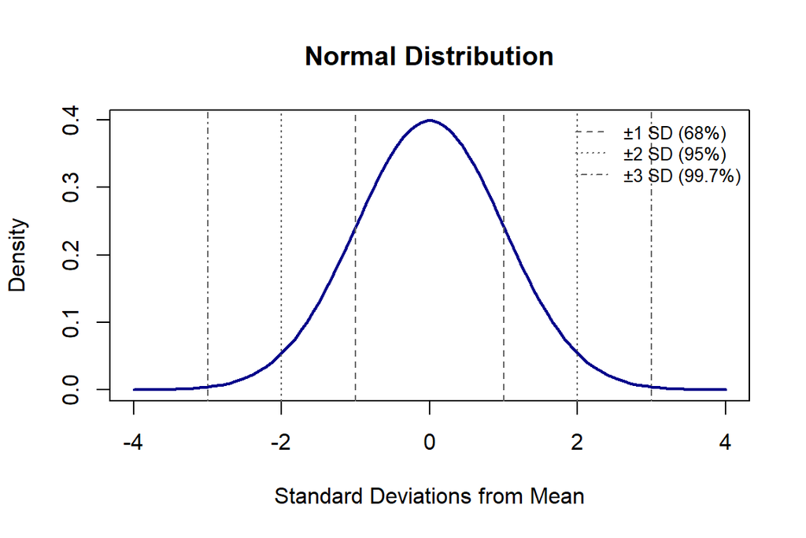

# Why Does Normality Matter?

Many statistical tests assume normality — especially:

- **t-tests**
- **ANOVA**
- **Regression**

We assume:

> “If the sample comes from a normal distribution, the test results are valid.”

Fortunately, many tests are **robust** to small violations.

# Central Limit Theorem (CLT)

The **CLT** says:

> The distribution of the sample mean becomes approximately **normal** as the sample size increases, even if the data are not normal.

This allows us to:

- Use t-tests and CIs on non-normal data
- Rely on sampling distributions instead of raw data

CLT usually kicks in around **n ≥ 30**

# Graphical Checks for Normality

Three useful visual tools:

- **Histogram** — see symmetry, outliers
- **Density Plot** — smoother histogram
- **QQ Plot** — plot of quantiles vs theoretical normal values

**Example: Histogram + Density Plot**

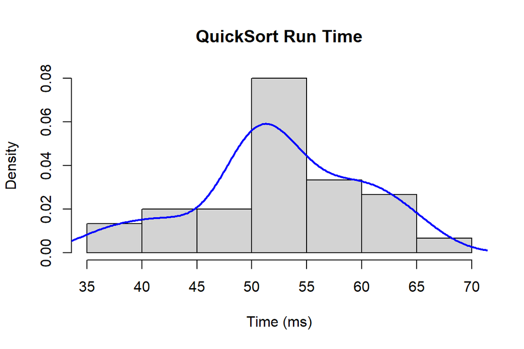

# QQ Plot (Quantile–Quantile Plot)

In a QQ plot:

- Points should lie on a straight line
- Curves at ends → skewness
- Strong deviations → non-normal

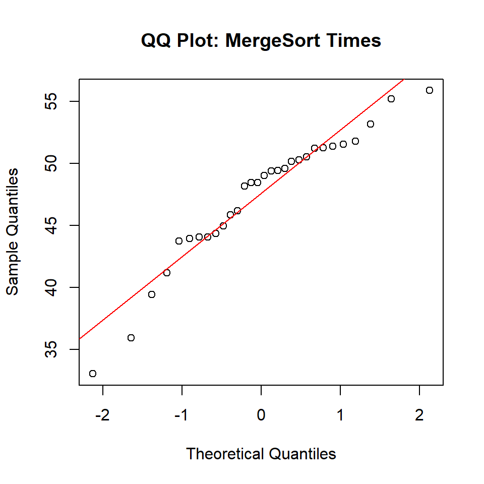

# Formal Test: Shapiro-Wilk Test

Tests whether data are normally distributed.

```r
shapiro.test(ms)
```

```
##
##  Shapiro-Wilk normality test
##
## data:  ms
## W = 0.93428, p-value = 0.06386
```

Interpretation:

- **H₀**: Data are from a normal distribution
- **H₁**: Data are not normal
- If p > 0.05 → fail to reject H₀ → data are *normal enough*

# What Does “Assume Normality” Mean?

It doesn’t mean your data must be perfect.

It means:

- You’ve **checked assumptions**
- The data are **close enough**
- You can justify using parametric tests

# Confidence Intervals and Statistical Inference

After describing our data and checking assumptions, we’re ready for **inference** — making conclusions about a population based on sample data.

The first tool of inference is the **confidence interval**.

**What Is a Confidence Interval?**

A **confidence interval (CI)** is a range of values likely to contain the **true population parameter** (like a mean).

# How to Interpret “95% Confidence”

It **does not mean** there’s a 95% chance the true value lies in one specific interval.

It means:

> If we repeated this experiment 100 times, 95 of those intervals would contain the true value.

It’s about the **method**, not one single outcome.

# Confidence Interval Formula

The general formula for a CI is:

$$\text{CI} = \bar{x} \pm t \cdot \text{SE}$$

Where:

- $\bar{x}$: sample mean
- $t$: critical value from the t-distribution
- **SE**: standard error = $s / \sqrt{n}$

**CI vs Standard Error**

**Standard Error (SE)** shows **how much sample means vary**:

$$SE = \frac{s}{\sqrt{n}}$$

The **CI** uses SE to build a range:

- SE = “spread of sample means”
- CI = “range of plausible population values”

# Computing Confidence Intervals in R

We can use `t.test()` to compute the mean and its confidence interval:

```r
qs_data <- algo_data$Time_ms[algo_data$Algorithm == "QuickSort"]
ms_data <- algo_data$Time_ms[algo_data$Algorithm == "MergeSort"]

t.test(qs_data)$conf.int
```

```
## [1] 49.59971 55.22333
## attr(,"conf.level")
## [1] 0.95
```

```r
t.test(ms_data)$conf.int
```

```
## [1] 45.42997 49.35095
## attr(,"conf.level")
## [1] 0.95
```

This gives the **95% confidence interval** around the mean run-time.

# Visualizing Confidence Intervals

We can plot mean ± CI error bars for each algorithm.

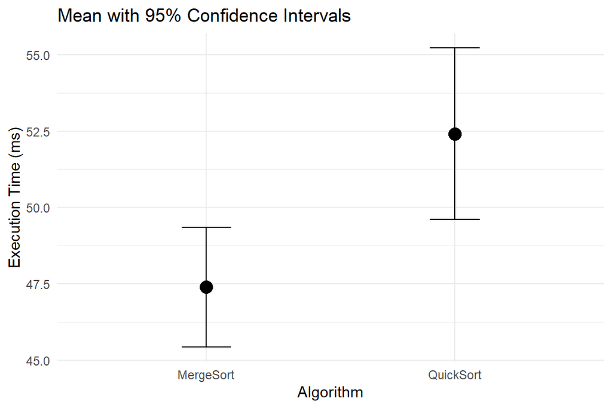

# CI for the Difference in Means

What if we want to compare MergeSort and QuickSort directly?

```r
t.test(Time_ms ~ Algorithm, data = algo_data)$conf.int
```

```
## [1] -8.384496 -1.657631
## attr(,"conf.level")
## [1] 0.95
```

If the CI includes 0 → **no significant difference**  
If it excludes 0 → **significant difference**

# Example Interpretation

Suppose the CI is:

```
[-8.38, -1.66]
```

Interpretation: - We are 95% confident MergeSort is faster by **between 1.66 and 8.38 ms** - CI does **not include 0** → result is **statistically significant**

# Summary: Confidence Intervals

| Concept | Purpose |
| --- | --- |
| CI | Range of plausible population values |
| 95% CI | 95 out of 100 such intervals contain the true value |
| CI includes 0 | No significant difference |
| CI excludes 0 | Significant difference |
| Narrow CI | More precision (less variability) |

Confidence intervals are a powerful tool for **quantifying uncertainty** — and they naturally lead us into **hypothesis testing**.

# Foundations of Hypothesis Testing

Once we have summary statistics and confidence intervals, we’re ready for formal decision-making.

**Hypothesis testing** helps us answer questions like: > “Is MergeSort significantly faster than QuickSort?”

It is the standard method for drawing scientific conclusions from data.

**What Is a Hypothesis?**

A **hypothesis** is a testable statement about a population or process.

It must be:

- **Testable** — can be confirmed or refuted with data
- **Falsifiable** — you can imagine evidence against it
- **Specific** — clear about what is being measured

# Types of Hypotheses

We always define **two hypotheses**:

- **Null Hypothesis (H₀)**  
  The default assumption — no difference, no effect  
  *E.g., “The algorithms have equal mean run-time”*
- **Alternative Hypothesis (H₁)**  
  What we want to show — there is a difference or effect  
  *E.g., “MergeSort is faster than QuickSort”*

We test **whether we can reject H₀** in favor of H₁.

# What Makes a Good Hypothesis?

A strong hypothesis should: - Be based on theory or prior research  
- Identify specific variables  
- Be framed for statistical testing  
- Use clear operational definitions

Examples:

| Research Question | H₀ | H₁ |
| --- | --- | --- |
| Is MergeSort faster? | µ₁ = µ₂ | µ₁ < µ₂ |
| Do students prefer UI A or B? | Equal preferences | At least one differs |
| Is crash rate linked to platform? | Independent | Dependent |

# The Logic of Hypothesis Testing

1. **Assume** H₀ is true
2. Collect data
3. Calculate how likely the data are **if H₀ were true**
4. If the data are **very unlikely**, reject H₀

This logic uses the **p-value** to quantify that likelihood.

**What Is a p-value?**

The **p-value** is the probability of observing your results (or more extreme), **assuming H₀ is true**.

- Small p-value → data are unlikely under H₀
- Large p-value → data are plausible under H₀

> It is **not** the probability that H₀ is true.

# Interpreting the p-value

| p-value | Interpretation |
| --- | --- |
| ≤ 0.05 | Statistically significant — reject H₀ |
| > 0.05 | Not significant — fail to reject H₀ |

Significance level (α) is usually set at **0.05**

# Type I and Type II Errors

| Type | Description | Risk Symbol |
| --- | --- | --- |
| **Type I Error** | Rejecting H₀ when it is actually true | α |
| **Type II Error** | Failing to reject H₀ when it is false | β |

Reducing one type often increases the other.  
We aim to **balance** them.

# One-Tailed vs Two-Tailed Tests

- **Two-tailed**: Checks for **any** difference  
  *H₁: µ₁ ≠ µ₂*
- **One-tailed**: Checks for a **specific** direction  
  *H₁: µ₁ < µ₂*

Use **one-tailed only** when justified by theory — not after looking at data!

# The Significance Level (α)

We set a threshold to control Type I error:

- Typically: **α = 0.05**
- Stricter for high-risk domains: α = 0.01

We compare:

- If **p ≤ α** → reject H₀ (significant)
- If **p > α** → fail to reject H₀ (not significant)

# Summary: Hypothesis Testing Flow

| Step | Description |
| --- | --- |
| 1. State H₀ and H₁ | Define competing hypotheses |
| 2. Choose α | Set risk tolerance (usually 0.05) |
| 3. Compute p-value | Based on sample and test |
| 4. Compare p to α | Decide whether to reject H₀ |
| 5. Interpret | Report significance and effect size |

This process will now guide us into **specific tests** — starting with the **t-test** for comparing means.

# Comparing Means: t-Tests

When your outcome is **numeric** and you want to compare **means**, the most common tool is the **t-test**.

There are three main types:

- One-sample t-test
- Independent two-sample t-test
- Paired-sample t-test

We’ll explore each with assumptions, examples, and interpretation.

# One-Sample t-Test

**Use when**: You compare a sample mean to a known value.

> Is MergeSort’s mean run-time different from 50ms?

```r
ms_data <- algo_data$Time_ms[algo_data$Algorithm == "MergeSort"]
t.test(ms_data, mu = 50)
```

```
##
##  One Sample t-test
##
## data:  ms_data
## t = -2.7223, df = 29, p-value = 0.01085
## alternative hypothesis: true mean is not equal to 50
## 95 percent confidence interval:
##  45.42997 49.35095
## sample estimates:
## mean of x
##  47.39046
```

- H₀: µ = 50
- H₁: µ ≠ 50

Reject H₀ if the p-value is less than 0.05.

# Independent Two-Sample t-Test

**Use when**: You compare two independent groups.

> Is there a significant difference in mean run-time between MergeSort and QuickSort?

```r
t.test(Time_ms ~ Algorithm, data = algo_data, var.equal = FALSE)
```

```
##
##  Welch Two Sample t-test
##
## data:  Time_ms by Algorithm
## t = -2.9959, df = 51.806, p-value = 0.004192
## alternative hypothesis: true difference in means between group MergeSort and group QuickSort is not equal to 0
## 95 percent confidence interval:
##  -8.384496 -1.657631
## sample estimates:
## mean in group MergeSort mean in group QuickSort
##                47.39046                52.41152
```

- H₀: µ₁ = µ₂
- H₁: µ₁ ≠ µ₂

Welch’s t-test (`var.equal = FALSE`) handles unequal variances.

# Paired-Sample t-Test

**Use when**: You compare two values from the **same subject** (e.g., two algorithms on the same input).

### Simulated Paired Data

```r
set.seed(123)
paired_data <- data.frame(
  Input = 1:30,
  QuickSort = rnorm(30, 52, 6),
  MergeSort = rnorm(30, 48, 5)
)

t.test(paired_data$QuickSort, paired_data$MergeSort, paired = TRUE)
```

```
##
##  Paired t-test
##
## data:  paired_data$QuickSort and paired_data$MergeSort
## t = 2.001, df = 29, p-value = 0.05483
## alternative hypothesis: true mean difference is not equal to 0
## 95 percent confidence interval:
##  -0.06243577  5.71380733
## sample estimates:
## mean difference
##        2.825686
```

# Assumptions of the t-Test

| Assumption | Description |
| --- | --- |
| Normality | Each group’s data ~ normal distribution |
| Equal variances | Use Welch’s test if not true |
| Independence | Observations are not repeated |
| Interval-level data | Values must be numeric and continuous |

Violations of these assumptions lead to **non-parametric tests** (we’ll cover these later).

# Visualizing Group Differences

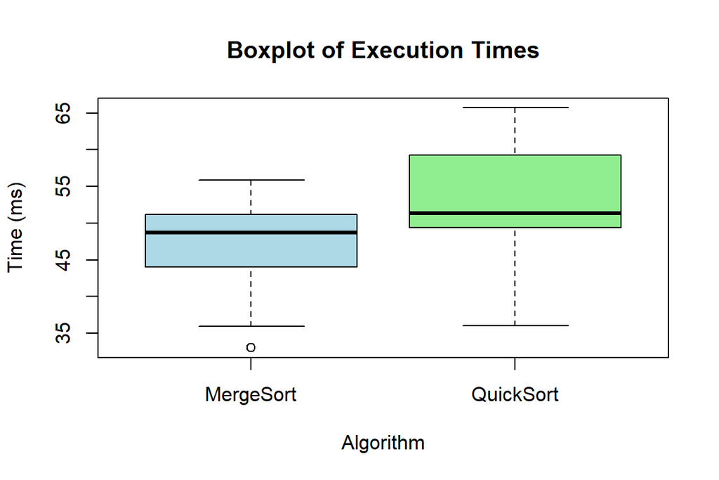

```r
boxplot(Time_ms ~ Algorithm, data = algo_data,
        col = c("lightblue", "lightgreen"),
        main = "Boxplot of Execution Times",
        ylab = "Time (ms)")
```

Use boxplots and CI bars to complement test results.

# Summary: Which t-Test?

| Test | Use Case | Function |
| --- | --- | --- |
| One-sample t-test | Sample vs fixed value | `t.test(x, mu = val)` |
| Two-sample t-test | Two independent groups | `t.test(y ~ group)` |
| Paired-sample t-test | Two related measurements | `t.test(x, y, paired = TRUE)` |

# Comparing 3+ Groups: ANOVA

When comparing **more than two groups**, we use **ANOVA** instead of multiple t-tests to avoid inflating the Type I error rate.

ANOVA tells us:

> “Is there **any** significant difference between group means?”

We’ll explore:

- One-way ANOVA
- Two-way ANOVA
- Post-hoc tests (Tukey HSD)
- Assumptions and visual inspection

# One-Way ANOVA: Setup

Let’s simulate a third algorithm: HeapSort

```r
set.seed(2025)
qs <- rnorm(30, mean = 52, sd = 6)
ms <- rnorm(30, mean = 48, sd = 5)
hs <- rnorm(30, mean = 50, sd = 4.5)

algo3_data <- data.frame(
  Algorithm = rep(c("QuickSort", "MergeSort", "HeapSort"), each = 30),
  Time_ms = c(qs, ms, hs)
)
```

# Running One-Way ANOVA

```r
anova_model <- aov(Time_ms ~ Algorithm, data = algo3_data)
summary(anova_model)
```

```
##             Df Sum Sq Mean Sq F value  Pr(>F)
## Algorithm    2  408.2  204.12   7.499 0.00099 ***
## Residuals   87 2368.2   27.22
## ---
## Signif. codes:  0 '***' 0.001 '**' 0.01 '*' 0.05 '.' 0.1 ' ' 1
```

- H₀: µ₁ = µ₂ = µ₃ (all means are equal)
- H₁: At least one group differs

If p < 0.05 → Reject H₀ → At least one mean is significantly different

# Post-Hoc Testing: Tukey HSD

ANOVA tells us **there is a difference**, but not **which groups differ**.

Use **Tukey’s Honest Significant Difference (HSD)** to compare all pairs:

```r
TukeyHSD(anova_model)
```

```
##   Tukey multiple comparisons of means
##     95% family-wise confidence level
##
## Fit: aov(formula = Time_ms ~ Algorithm, data = algo3_data)
##
## $Algorithm
##                           diff        lwr      upr     p adj
## MergeSort-HeapSort  -0.9764591 -4.1886528 2.235735 0.7494717
## QuickSort-HeapSort   3.9499434  0.7377497 7.162137 0.0118579
## QuickSort-MergeSort  4.9264025  1.7142088 8.138596 0.0012577
```

Look for:

- Which comparisons are significant
- Confidence intervals that do **not** include 0

# Visualizing Group Differences

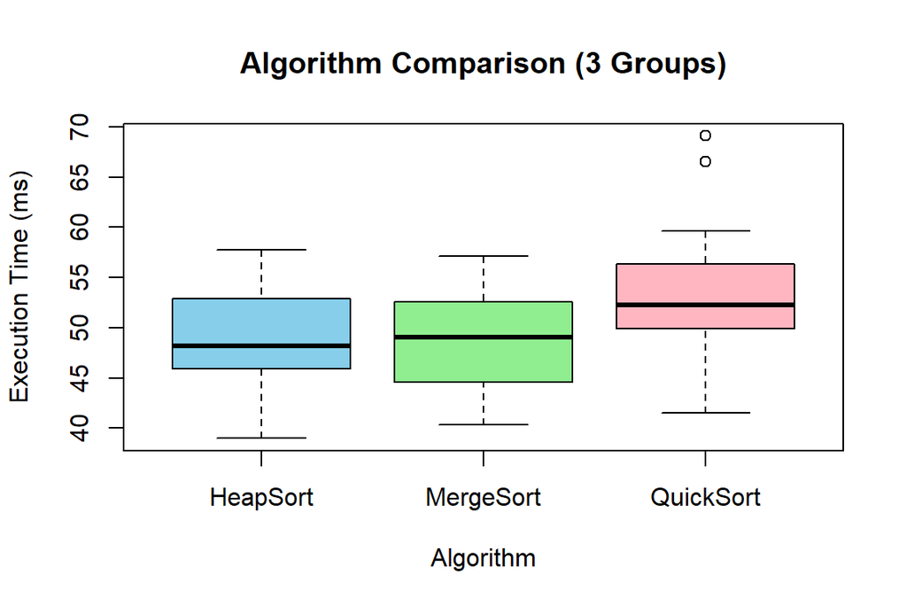

```r
boxplot(Time_ms ~ Algorithm, data = algo3_data,
        col = c("skyblue", "lightgreen", "lightpink"),
        ylab = "Execution Time (ms)",
        main = "Algorithm Comparison (3 Groups)")
```

# Assumptions of ANOVA

| Assumption | How to Check |
| --- | --- |
| **Independence** | Experimental design |
| **Normality** | Use QQ plot or Shapiro test per group |
| **Equal variances** | Use Bartlett or Levene test |

### Example: Test for Equal Variances

```r
bartlett.test(Time_ms ~ Algorithm, data = algo3_data)
```

```
##
##  Bartlett test of homogeneity of variances
##
## data:  Time_ms by Algorithm
## Bartlett's K-squared = 1.3655, df = 2, p-value = 0.5052
```

# Two-Way ANOVA: Including More Factors

Let’s add **Input Size** as a second factor: Small vs Large datasets.

```r
set.seed(123)
algo <- rep(c("QuickSort", "MergeSort", "HeapSort"), times = 30)
size <- rep(rep(c("Small", "Large"), each = 15), times = 3)

runtime <- rnorm(90,
                 mean = ifelse(algo == "MergeSort", 48,
                          ifelse(algo == "QuickSort", 52, 50)) +
                        ifelse(size == "Large", 3, 0),
                 sd = 4.5)

two_way_data <- data.frame(
  Algorithm = algo,
  InputSize = size,
  Time_ms = runtime
)
```

# Two-Way ANOVA Model

```r
two_way_model <- aov(Time_ms ~ Algorithm * InputSize, data = two_way_data)
summary(two_way_model)
```

```
##                     Df Sum Sq Mean Sq F value   Pr(>F)
## Algorithm            2  477.3  238.67  14.485 3.94e-06 ***
## InputSize            1  142.4  142.44   8.645  0.00424 **
## Algorithm:InputSize  2    4.9    2.45   0.149  0.86182
## Residuals           84 1384.1   16.48
## ---
## Signif. codes:  0 '***' 0.001 '**' 0.01 '*' 0.05 '.' 0.1 ' ' 1
```

This tests:

- Main effect of **Algorithm**
- Main effect of **Input Size**
- **Interaction** between them

A significant interaction means:

> The effect of Algorithm **depends on Input Size**

# Summary: ANOVA

| Test | Use Case | Tool |
| --- | --- | --- |
| One-way ANOVA | 3+ group means | `aov(y ~ group)` |
| Tukey HSD | Post-hoc pairwise | `TukeyHSD()` |
| Bartlett Test | Equal variances | `bartlett.test()` |
| Two-way ANOVA | 2 factors | `aov(y ~ A * B)` |

# Chi-Squared Tests for Categorical Data

When your data are **categorical** (e.g., success/fail, error type, UI preference), you need a test designed for **counts**, not means.

The **Chi-squared (χ²) test** helps answer questions like:

- Do observed results match expectations?
- Are two categorical variables related?

# Two Main Types of Chi-Squared Tests

| Test | Purpose |
| --- | --- |
| **Goodness-of-Fit** | Do observed counts match expected proportions? |
| **Test of Independence** | Are two categorical variables related? |

We’ll explore both with examples.

# Chi-Squared Goodness-of-Fit

**Use when**: You compare observed outcomes to an expected distribution.

> Example: HeapSort ran 60 times  
> You expect 95% Success, 5% Fail.  
> You observed: 54 Success, 6 Fail

```r
observed <- c(Success = 54, Fail = 6)
expected_probs <- c(0.95, 0.05)
chisq.test(x = observed, p = expected_probs)
```

```
##
##  Chi-squared test for given probabilities
##
## data:  observed
## X-squared = 3.1579, df = 1, p-value = 0.07556
```

# Interpreting Goodness-of-Fit

- H₀: The observed distribution matches the expected
- H₁: The distributions differ
- If p < 0.05 → significant → reject H₀

This helps check whether results conform to a known or ideal pattern.

# Chi-Squared Test of Independence

**Use when**: You want to know if **two categorical variables are associated**.

> Example: Is success rate dependent on the algorithm used?

**Simulated Example (Success/Failure by Algorithm)**

```
##
##  Pearson's Chi-squared test
##
## data:  tab
## X-squared = 9.6041, df = 2, p-value = 0.008213
```

# Interpreting the Test of Independence

- H₀: The variables are independent (algorithm does not affect outcome)
- H₁: The variables are dependent (algorithm affects outcome)

If **p < 0.05**, we reject H₀ and conclude that the outcome **depends** on the algorithm.

# Assumptions of the Chi-Squared Test

| Assumption | How to Handle |
| --- | --- |
| Independent observations | No repeated measurements |
| Expected count ≥ 5 in each cell | Use Fisher’s Exact Test if violated |
| Sufficient total sample size | Larger n = better approximation |

# When Expected Counts Are Too Small

If any expected cell count is **less than 5**, consider:

- Combining similar categories
- Using **Fisher’s Exact Test** (especially for 2x2 tables)

```r
fisher.test(tab)  # if dimensions are small
```

```
##
##  Fisher's Exact Test for Count Data
##
## data:  tab
## p-value = 0.01512
## alternative hypothesis: two.sided
```

# Summary: Chi-Squared Tests

| Test Type | Use Case | R Function |
| --- | --- | --- |
| Goodness-of-fit | One variable vs expected proportions | `chisq.test(x, p)` |
| Test of independence | Two categorical variables | `chisq.test(table)` |
| Small samples | Any 2x2 table | `fisher.test()` |

These tests are essential when your research deals with:

- User preferences
- Pass/fail outcomes
- Classification results
- Any system behavior encoded as **categories**

# Correlation Analysis

When working with **two numeric variables**, we often ask:

> “As one variable increases, does the other also increase (or decrease)?”

**Correlation analysis** helps answer this by measuring:

- The **strength** of the relationship
- The **direction** (positive or negative)

# Types of Correlation

| Method | Use When |
| --- | --- |
| **Pearson** | Linear relationship, numeric data, normality |
| **Spearman** | Ordinal data or non-linear monotonic relationship |
| **Kendall (optional)** | Small samples, tied ranks |

We’ll focus on Pearson and Spearman.

# Pearson Correlation Coefficient (r)

Used for:

- Two continuous, normally distributed variables
- Linear relationships

Values range from:

- +1: perfect positive correlation
- 0: no correlation
- −1: perfect negative correlation

```r
set.seed(1)
input_size <- seq(100, 1000, length.out = 50)
qs_runtime <- 0.05 * input_size + rnorm(50, mean = 0, sd = 10)

cor(input_size, qs_runtime)  # Pearson correlation
```

```
## [1] 0.8478924
```

# Spearman Rank Correlation

Used for:

- Ordinal or **non-linear monotonic** relationships
- Data with **outliers** or **non-normality**

```r
cor(input_size, qs_runtime, method = "spearman")
```

```
## [1] 0.8690036
```

Compares **ranks** instead of raw values.

# Scatterplot: Input Size vs Run Time

Always visualize your correlations — outliers and non-linear trends are not visible from `cor()` alone.

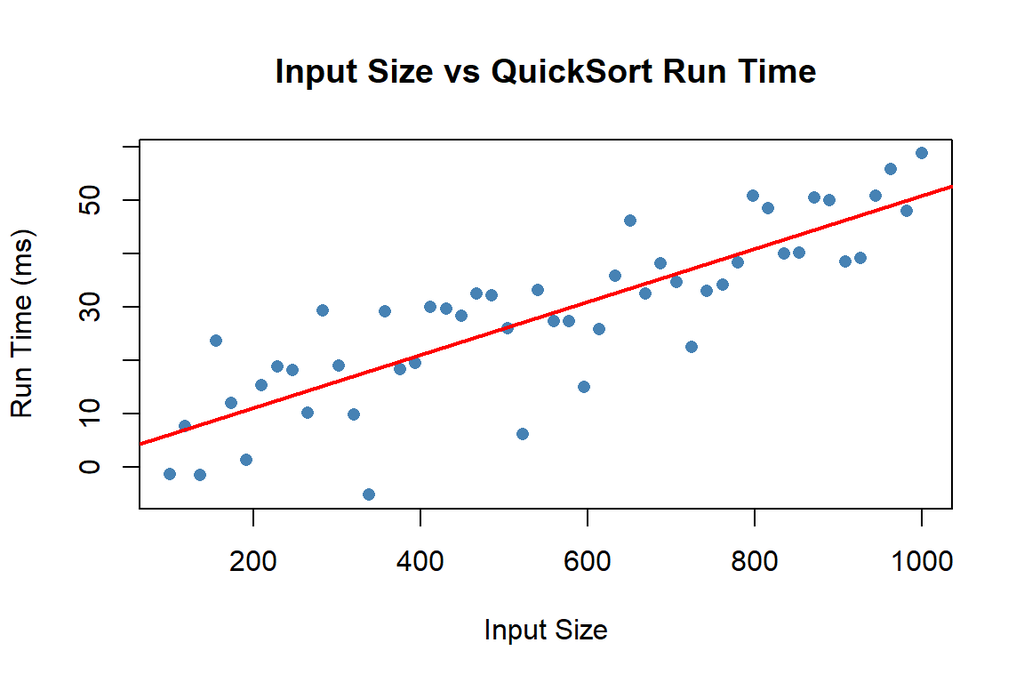

**Correlation Matrix (Multiple Variables)**

You can quickly assess relationships between several numeric variables using a correlation matrix:

```
##            Size QuickSort Noise Quadratic
## Size       1.00      0.85 -0.08      0.98
## QuickSort  0.85      1.00 -0.09      0.84
## Noise     -0.08     -0.09  1.00     -0.07
## Quadratic  0.98      0.84 -0.07      1.00
```

Use this to explore pairwise relationships at a glance.

# Correlation ≠ Causation

Just because two variables move together does **not** mean one causes the other.

> Correlation may result from:
> - Coincidence
> - Confounding (a third variable affects both)
> - Reverse causality

Always interpret correlations with **context and caution**.

# Summary: Correlation Analysis

| Concept | Pearson | Spearman |
| --- | --- | --- |
| Measures | Linear association | Monotonic association |
| Sensitive to | Outliers, skew | Less sensitive |
| Use with | Numeric, normal data | Ranked or skewed data |
| Output | -1 to +1 (strength & direction) | Same scale, different method |

Correlation is a **powerful exploratory tool**, but should be followed by **modeling or experimental design** when aiming for causal claims.

# Non-Parametric Alternatives

Sometimes, your data:

- Isn’t **normally distributed**
- Has **small sample sizes**
- Includes **outliers** or **ranks** instead of true numeric values

In these cases, we turn to **non-parametric tests**.

> These tests don’t rely on distributional assumptions  
> and operate on **ranks** instead of raw data.

# When to Use Non-Parametric Tests

Use them when:

- Normality is violated
- You’re working with **ordinal** (ranked) data
- Your sample size is too small for the Central Limit Theorem to apply
- Outliers distort the mean

# Wilcoxon Signed-Rank Test

Alternative to: **Paired t-test**

**Use when**: - You have two **related** groups  
- The **differences are not normally distributed**

```r
qs <- rnorm(30, mean = 52, sd = 7)
ms <- rnorm(30, mean = 48, sd = 7)

wilcox.test(qs, ms, paired = TRUE)
```

```
##
##  Wilcoxon signed rank exact test
##
## data:  qs and ms
## V = 358, p-value = 0.008705
## alternative hypothesis: true location shift is not equal to 0
```

- H₀: Median difference = 0
- H₁: Median difference ≠ 0

# Mann–Whitney U Test (Wilcoxon Rank-Sum)

Alternative to: **Independent two-sample t-test**

**Use when**:

- Comparing **two independent groups**
- The data are **skewed** or ordinal

```r
group <- rep(c("QuickSort", "MergeSort"), each = 30)
times <- c(qs, ms)

wilcox.test(times ~ group)
```

```
##
##  Wilcoxon rank sum exact test
##
## data:  times by group
## W = 283, p-value = 0.01307
## alternative hypothesis: true location shift is not equal to 0
```

- Compares whether one group tends to rank higher than the other

# Kruskal–Wallis Test

Alternative to: **One-way ANOVA**

**Use when**: - You want to compare **3 or more groups**  
- Data is not normally distributed

```r
group <- rep(c("QuickSort", "MergeSort", "HeapSort"), each = 30)
times <- c(
  rnorm(30, mean = 52, sd = 6),
  rnorm(30, mean = 48, sd = 6),
  rnorm(30, mean = 50, sd = 6)
)

kruskal.test(times ~ group)
```

```
##
##  Kruskal-Wallis rank sum test
##
## data:  times by group
## Kruskal-Wallis chi-squared = 3.4113, df = 2, p-value = 0.1817
```

If significant → follow up with pairwise Wilcoxon tests.

# Summary: Parametric vs Non-Parametric

| Goal | Parametric Test | Non-Parametric Alternative |
| --- | --- | --- |
| Compare one sample to a value | One-sample t-test | (rarely needed) |
| Compare two independent groups | Two-sample t-test | Mann–Whitney U |
| Compare two paired groups | Paired t-test | Wilcoxon signed-rank |
| Compare 3+ groups | One-way ANOVA | Kruskal–Wallis |

# When to Prefer Non-Parametric Tests

Choose non-parametric tests if:

- The **normality assumption fails**
- You’re analyzing **ordinal/ranked data**
- You want a method **robust to outliers**

They’re less powerful than parametric tests **when assumptions are met**, but much more **reliable** when assumptions are **violated**.

# Choosing the Right Statistical Test

| Goal | Data | Groups | Assumptions Met? | Test |
| --- | --- | --- | --- | --- |
| Compare to known value | Numeric | 1 | ✔️ | One-sample t-test |
| Compare two groups | Numeric | 2 (independent) | ✔️ | Two-sample t-test |
| Compare two paired sets | Numeric | 2 (paired) | ✔️ | Paired t-test |
| Compare 3+ groups | Numeric | 3+ | ✔️ | ANOVA |
| Compare ranks/medians | Ordinal / skewed | 2 | ❌ | Mann–Whitney U / Wilcoxon |
| Compare 3+ medians | Ordinal / skewed | 3+ | ❌ | Kruskal–Wallis |
| Compare counts to expected | Categorical | 1 variable | – | Chi-squared (Goodness-of-Fit) |
| Association between categories | Categorical | 2 variables | – | Chi-squared (Independence) |
| Correlation (linear) | Numeric | 2 vars | ✔️ | Pearson |
| Correlation (ranked) | Ordinal / skewed | 2 vars | ❌ | Spearman |